# Understanding the technological transition based on cultural transmission biases during the Late Pleistocene in Korea

Gayoung Park

Ben Marwick

07 July, 2020

Abstract

```
## here() starts at /Users/gayoungp/CTtps
```

# 1 Introduction

(Polly, 2018) 1. What are our research questions? - Understanding technological transition during the Late Pleistocene in Korea base on Cultural transmission. - What are the social contexts led to the technological transition

2. What is our archaeological background? -SP was started in Korean Peninsula -> spread to Japan -Why SP important, Why we care -Current explantion of SP dispersal: migration vs in situ, in between The evidence of the two main models: proportion of SP in assemblage, Y chromosome (two groups of people), composition of assemblage (blade to flake ratio) -> no explanation about any mechanism/process/driver for the new technology -> lack of details of the lithic technology, human behavior
3. What is our conceptual framework?
- Evolutionary concepts that links stone artifacts to human behavior
- Cultural Evolution : the idea that cultural change constitutes an evolutionary process
- Same general concept of biological evolution: genetic change in population that is inherited over generations. Apply this concept to artifacts or cultural phenomena
- In this paper, I will use Cultural Transmission
- Cultural Transmssion: way that people learn and pass on information
- Transmission biases
- similar study (CT in stone artifacts) : Mesoudi&O’Brien, Bettinger&Eerkens, Garvey

[output not shown]

4. What are our methods?
- Framework: Bettinger&Eerkens

To investigate the specific relationship between technological innovations in Korea and the influence of social contexts, I will apply Bettinger and Eerkens’ (1999) approach because their focus on the introduction of new tool in a region is closely related to my research question about new technologies in Late Pleistocene Korea. I will focus on stemmed points in the Korean Paleolithic, a distinctive kind of projectile point similar to the points studied by Bettinger and Eerkens, to study transmission biases. I propose two models to investigate the social context of new technologies in Korea: a single-point origin model and multi-points origins model.

The single-point origin model proposes that the new technology appeared at a single point in Korea, and spread out from this single origin location via relatively long-distance trips, or a chain of direct transmission through multiple individuals. This model is similar to Bae’s migration model for the introduction of new tools in the Korean Paleolithic, but is not identical because the single point in my model could be a single point of indigenous innovation, rather than an external introduction (distinguishing between these two possibilities is beyond the scope of my project). This model predicts that if the new technologies appeared from a single origin, then model-based bias will have been important in the spread of the technology, and the metric attributes of artifacts from my sites will be strongly correlated, and there will be low variation between sites.

The multiple-points origin model proposes that new technology appeared independently at multiple locations on the Korean peninsula. This is analogous to Seong’s ‘in situ’ model of local innovation. This model proposes that the social context for the appearance of new tools is one of isolated groups with limited contact, where guided variation dominates transmission biases and innovations in material culture that are strongly determined by trial and error. This model predicts that attributes of artifacts will be poorly correlated and show high variation between sites.

** Expectation - The main measurements are correlation(+PCA) and CV. - The set of the two measurements would be like: 1) lower CV and higher correlation between sites, in this case, we will think that SPs were the result of model based bias and possibly had single origin. 2) higher CV and lower correlation between sites, for this case, we will thank that SPs were the result of guided variation and possibly had multiple origins. - We have three phases, but there are only two artifacts for the first phase. There are more artifacts and sites for the first phase but not eligible for this research because we gathered complete or almost complete shape of SPs. We excluded broken pieces. Therefore, we focus on the change from the 2nd phase to 3rd phase for understanding the process of SP’s dispersal in the Korean Peninsula. - Change from the 2nd to 3rd 1) less correlated: the two groups were not very related/locally developed 2) highly correlated: the two groups were related, had single source and then spread to other places - Site by site - Regional relationship? Province/cities

# 2 Background

# 3 Methods

Reading tps data and phase information of each artifact

Computing size attributes of the points by calculating distance between landmarks

Gather attributes from all artifacts

Box plot for each attributes

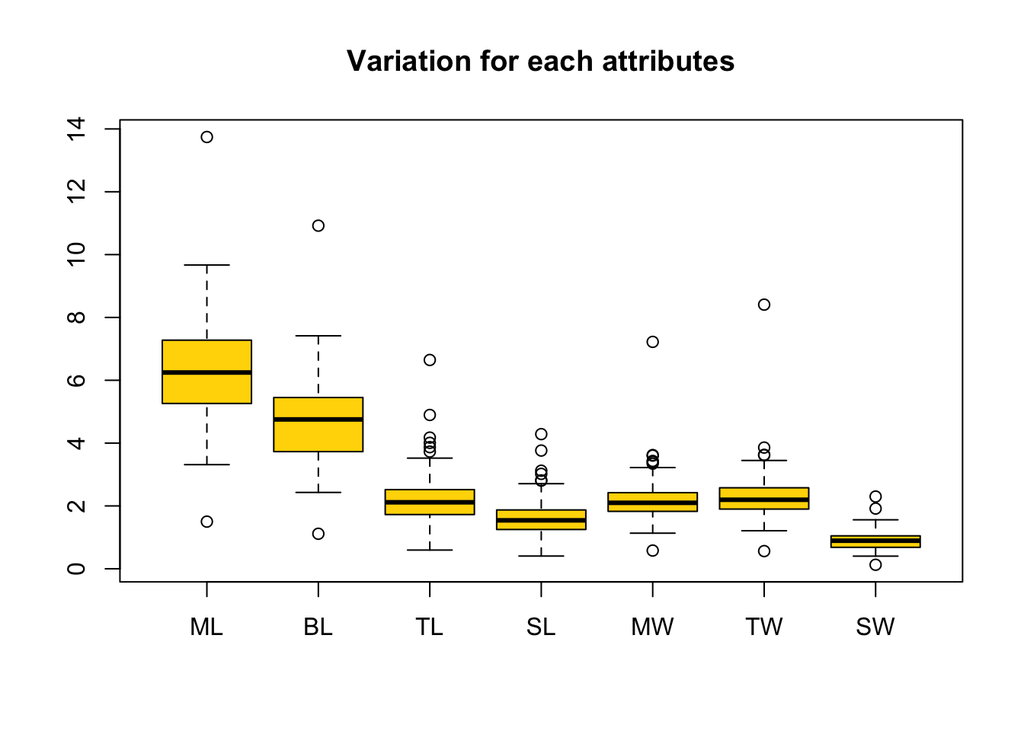

This boxplot indicates the overview of each attribute. We can see that ML and BL have wider variation compared to other attribtues. Since TL has relativelly less variable, ML variation is more depending on BL. Throughout time and region, dimension of SW is consistant.

It must be noted that all of this previously undertaken work has focused exclusively on the size (i.e., scale) of artifactual attributes and the patterns of variation that may be produced via copying error rates due to limits in size perception. However, variation in the overall shape of artifacts is also evidently important, given that aspects of shape may have specific functional or aesthetic properties (Schillinger et al. 2014).

Computing Coefficient or variation

```
#> # A tibble: 1 x 7
#>      ML    BL    TL    SL    MW    TW    SW
#>   <dbl> <dbl> <dbl> <dbl> <dbl> <dbl> <dbl>
#> 1  23.8  27.3  34.5  36.3  28.8  31.6  32.0
```

The coefficient of variation (CV) is the ratio of the standard deviation devided by mean. It shows the extent of variability from the mean.

Make a table of CVs for all variable grouped by site

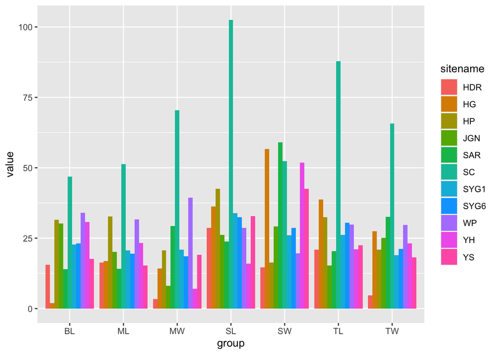

The plot shows CV values for different attributes The color of the bars represent different sites. Among tehs sites, we can see SC (Sachang) site has significantly high CV values. SC has two artifacts, one is from 1st phase and the other one is 2nd phase. We assume that this time difference and few number of artifacts may relate to the high CV value.

Make a table of CVs for all variable grouped by phase

BM: discuss this one first, this is the overview picture for our story:

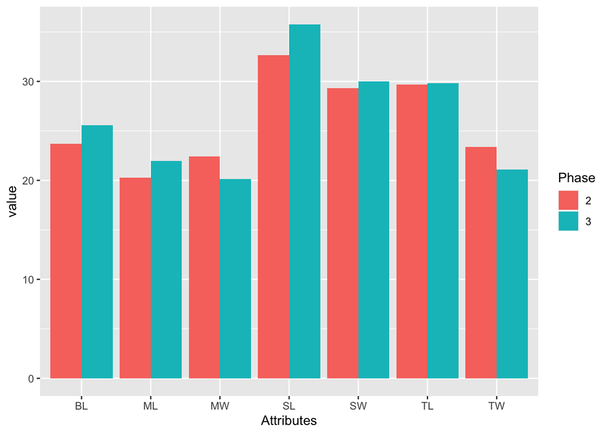

This plot shows the difference of CV in between 2nd and 3rd phase. For TL, both two phases have almost same values. For MW and TW, 3rd phase has lower values than the 2nd. The other 4 attributes show higher valeues in 3rd phase, which means less standardized in their shape during the latter period.

By the way, Previous research (Bettinger&Eerkins, Garvey) focused on Width of the projectile points along with weight to understand cultural transmssion. We haven’t figured out which attibutes would be more infortant than others yet.

BM: this discuss this one second, this is where we get into the details

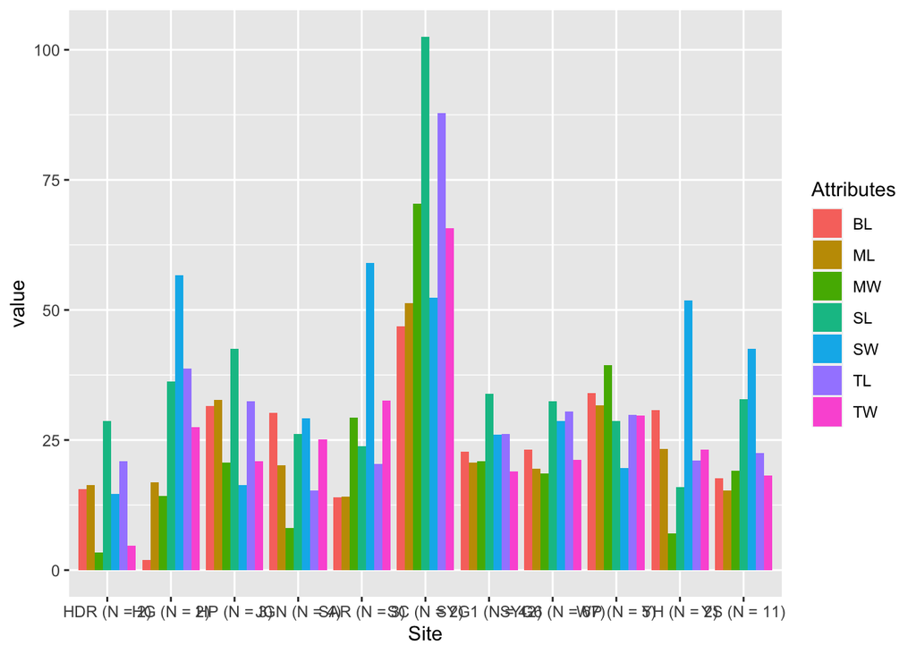

Unlike the previous plot, in this one, the bars represent different attributes. You can see that SC has highest CV values of most attributes. Overall, SW values are very high.

[figure not shown]

[figure not shown]

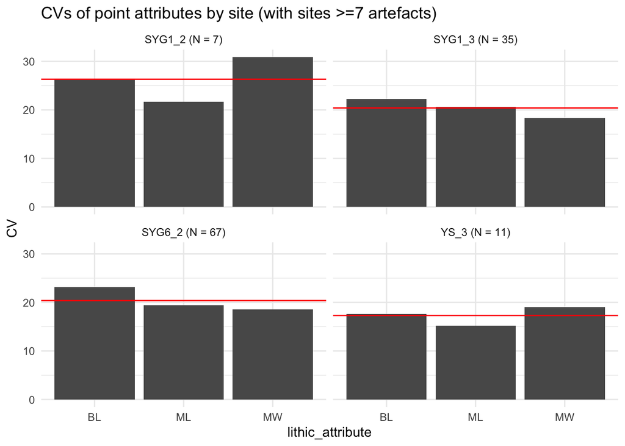

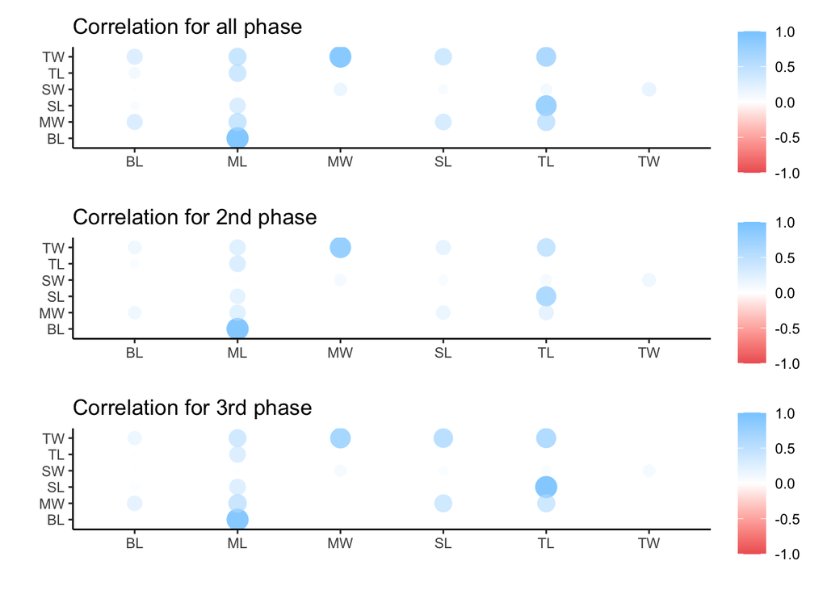

When it comes to the correlations between seven attributes, BL-ML, TW-MW, TL-TW, and TL-SL are relatively close to each other. There is no negative correlation among the attributes. Compared to the 2nd phase, in 3rd phase, correlations of SL with TW and MW, and TL with TWm SL, and MW get stronger. On the other hand, the correlation of TW-SW becomes weeker. Overall, the correlation between attributes became stronger from 2nd to 3rd phase.

Combined the two results of CV and correlation from 2nd to 3rd…

CV: lower in MW and TW, but higher in other 5 attribtues.

COR: overall correlation became stronger.

=> This combination doesn’t fit into the models.

Eerkens and Lipo (2005) demonstrated that the thickness of Rose Springs projectile points from Owens Valley (USA) varied according to the predictions of the random accumulated copying error model. However, the basal width of these projectile points exhibited less variation than expected, suggesting that some non-mutation process (i.e., some form of stabilizing selection such as conformity) was operating on this particular variable.

Principal component analysis

Principal Component Analysis is a technique to extract relevant information from a multivariate dataset and to express this information as a set of few new variables called principal components or dimensions (Cascalheira and Bicho, 2018).

We see some differences in artefact shape and size. Now we need to examins the PCA output numbers to describe in more details.

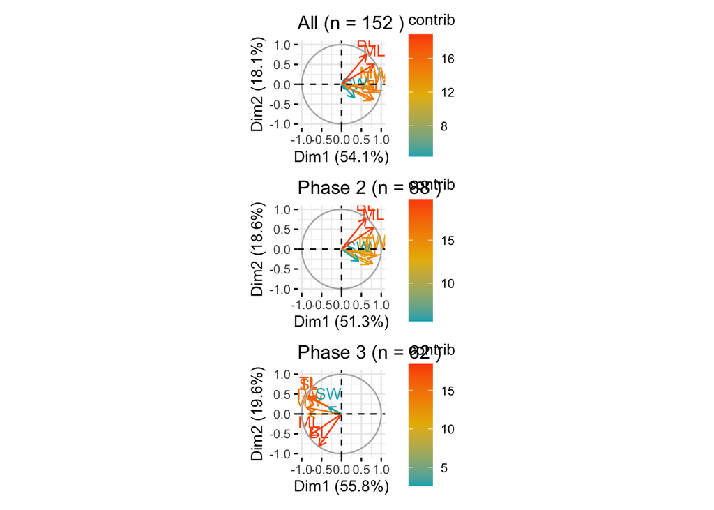

Overall, BL and ML have stronger influence than the other attributes and are related to each other but not with the other attributes throughout time. From the phase 2 to the phase 3, the proportion of TL and SL gets bigger and they are more related to SW.

SYG6 site data and analysis: artifacts from SYG6 site: now it has two layers, but the same phase (2nd)

```
#> # A tibble: 1 x 7
#>      ML    BL    TL    SL    MW    TW    SW
#>   <dbl> <dbl> <dbl> <dbl> <dbl> <dbl> <dbl>
#> 1  19.5  23.2  30.5  32.4  18.5  21.2  28.6
```

SYG1 site data and analysis: artifacts from SYG1 site, which include two differnt locations(excavation pits) and the artifacts are from different phase. SYG1_2 : 3rd phase SYG1_1: 2nd phase

```
#> # A tibble: 1 x 7
#>      ML    BL    TL    SL    MW    TW    SW
#>   <dbl> <dbl> <dbl> <dbl> <dbl> <dbl> <dbl>
#> 1  20.6  22.2  26.8  33.9  18.4  19.0  24.1
```

```
#> # A tibble: 1 x 7
#>      ML    BL    TL    SL    MW    TW    SW
#>   <dbl> <dbl> <dbl> <dbl> <dbl> <dbl> <dbl>
#> 1  21.7  26.4  23.1  35.8  30.9  20.0  36.6
```

Correlations for each site

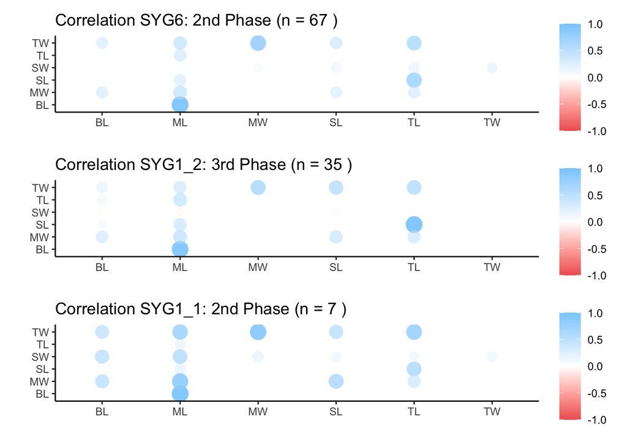

In this plot, we can see that the pattern of correlation for SYG6 and SYG1_1 are similar in terms of correlation based on ML/SL/TL with other attributes. Both are part of the phase 2. However, SYG1_2 is younger than the other two and the correlation based on SW become weaker.

When it comes to the difference between SYG6 and SYG1_1, the correlation between artifacts of SYG1_1 is stronger than SYG6.

PCA for each site

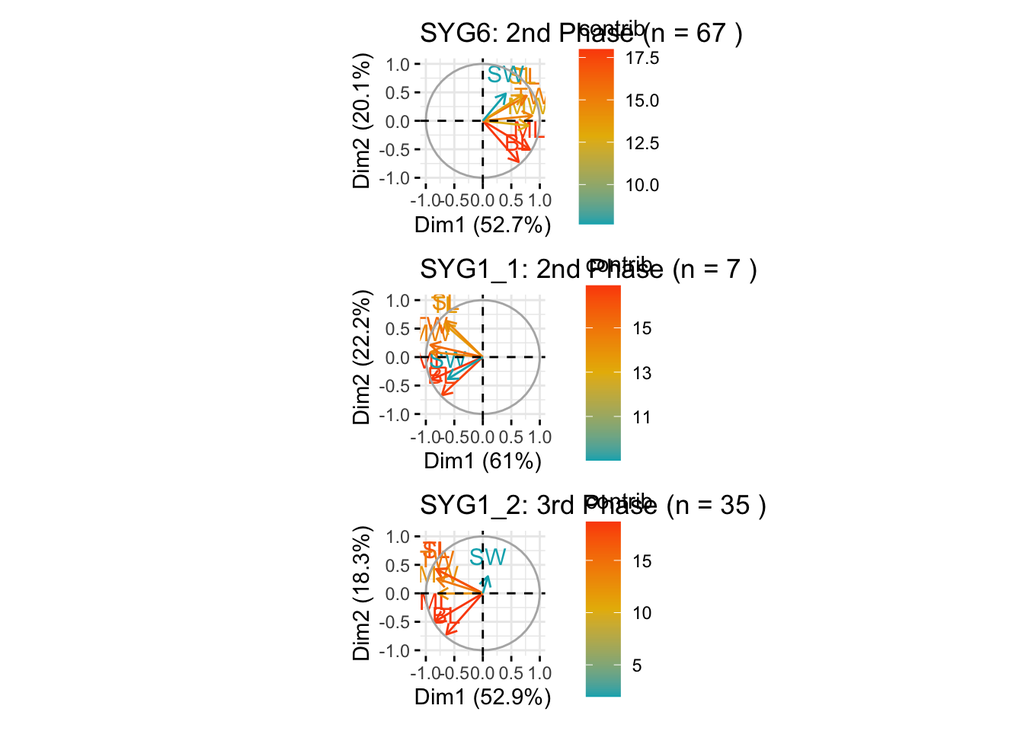

Unlike the correlation of the three units, PCA of the three are more various. Especially, SW is related to SL/TL in SYG6, related to ML/BL in SYG1_1, and unrelated to the other attributes in SYG1_2.

# 4 Results

# 5 Discussion

# 6 Conclusion

# 7 Acknowledgements

# 8 References

Cascalheira, J., Bicho, N., 2018. The use of lithic assemblages for the definition of short-term occupations in hunter-gatherer prehistory.

Polly, P.D., 2018. Geometric morphometrics, in: The Encyclopedia of Archaeological Sciences. American Cancer Society, pp. 1–5. https://doi.org/10.1002/9781119188230.saseas0258

### 8.0.1 Colophon

The current Git commit details are:

```
#> Local:    master /Users/gayoungp/CTtps
#> Remote:   master @ origin (https://github.com/parkgayoung/CTtps.git)
#> Head:     [77b6cea] 2020-06-12: changed headings of the plots
```